# Association Rules Project

Nuray Nasib

### Market Basket Analysis

One of the methods of association rules is market basket analysis. This type of method is basically a ‘if’ and ‘then’ rule. Simply put, if the consumer has a product in a basket, this approach determines the other items which the customer is most likely to buy. For example, if customers buy a beer then they are likely (with a 90 percent probability) to buy a bag of crisps. Mining such rules is very important in sales branch. Businesses may take advantage of these by organizing the store or catalogs in a specific manner, considering which items are more likely to be purchased together, setting up promotional promotions to promote the selling of a particular product or making customized discounts.

The most common laws (“if” and “then”) are among all the directions we are searching for. Those provisions are based on indicators:

- support shows how often itemset appears in the dataset;
- confidence indicates how often given rule is true. 1 means 100% correctness;
- expected confidence is confidence divided by number of transactions;
- lift indicates how more or less likely it is that there will occure a shopping pattern compared to the situation in which items are independent.

### Data

For the data, I will be using a fictional list of grocery transactions, which can be downloaded from github as it was published as a text file. It can be imported with read.table() function and then transformed into object of class transactions with read.transactions().

```r
library(stringr)
Groceries <- read.table("https://raw.githubusercontent.com/stedy/Machine-Learning-with-R-datasets/master/groceries.csv", sep=";")
head(Groceries)
```

```
##                                                                    V1
## 1              citrus fruit,semi-finished bread,margarine,ready soups
## 2                                        tropical fruit,yogurt,coffee
## 3                                                          whole milk
## 4                         pip fruit,yogurt,cream cheese ,meat spreads
## 5 other vegetables,whole milk,condensed milk,long life bakery product
## 6                      whole milk,butter,yogurt,rice,abrasive cleaner
```

```r
transactions <- str_split_fixed(Groceries$V1, ",", n = Inf)
head(transactions[,1:4])
```

```
##      [,1]               [,2]                  [,3]
## [1,] "citrus fruit"     "semi-finished bread" "margarine"
## [2,] "tropical fruit"   "yogurt"              "coffee"
## [3,] "whole milk"       ""                    ""
## [4,] "pip fruit"        "yogurt"              "cream cheese "
## [5,] "other vegetables" "whole milk"          "condensed milk"
## [6,] "whole milk"       "butter"              "yogurt"
##      [,4]
## [1,] "ready soups"
## [2,] ""
## [3,] ""
## [4,] "meat spreads"
## [5,] "long life bakery product"
## [6,] "rice"
```

```r
write.csv(transactions, file = "transactions.csv", row.names = F)
```

```r
library(arules)
Groceries <- read.transactions("transactions.csv", format = "basket", sep = ",", skip=1)
```

Groceries contains sales data from a local grocery store with 9835 transactions and 169 items (product groups). The summary shows some basic statistics of the data set. For example, that the data set is rather sparse with a density just above 2.6%, that “whole milk” is the most popular item and that the average transaction contains less than 5 items. Also I can state that there are 2159 transactions consisting only one item and there is a one transaction consisting of 32 items.

```r
summary(Groceries)
```

```
## transactions as itemMatrix in sparse format with
##  9835 rows (elements/itemsets/transactions) and
##  169 columns (items) and a density of 0.02609146
##
## most frequent items:
##       whole milk other vegetables       rolls/buns             soda
##             2513             1903             1809             1715
##           yogurt          (Other)
##             1372            34055
##
## element (itemset/transaction) length distribution:
## sizes
##    1    2    3    4    5    6    7    8    9   10   11   12   13   14   15   16
## 2159 1643 1299 1005  855  645  545  438  350  246  182  117   78   77   55   46
##   17   18   19   20   21   22   23   24   26   27   28   29   32
##   29   14   14    9   11    4    6    1    1    1    1    3    1
##
##    Min. 1st Qu.  Median    Mean 3rd Qu.    Max.
##   1.000   2.000   3.000   4.409   6.000  32.000
##
## includes extended item information - examples:
##             labels
## 1 abrasive cleaner
## 2 artif. sweetener
## 3   baby cosmetics
```

The below plot shows 10 most occuring products in the Groceries data.

```r
library(arulesViz)
```

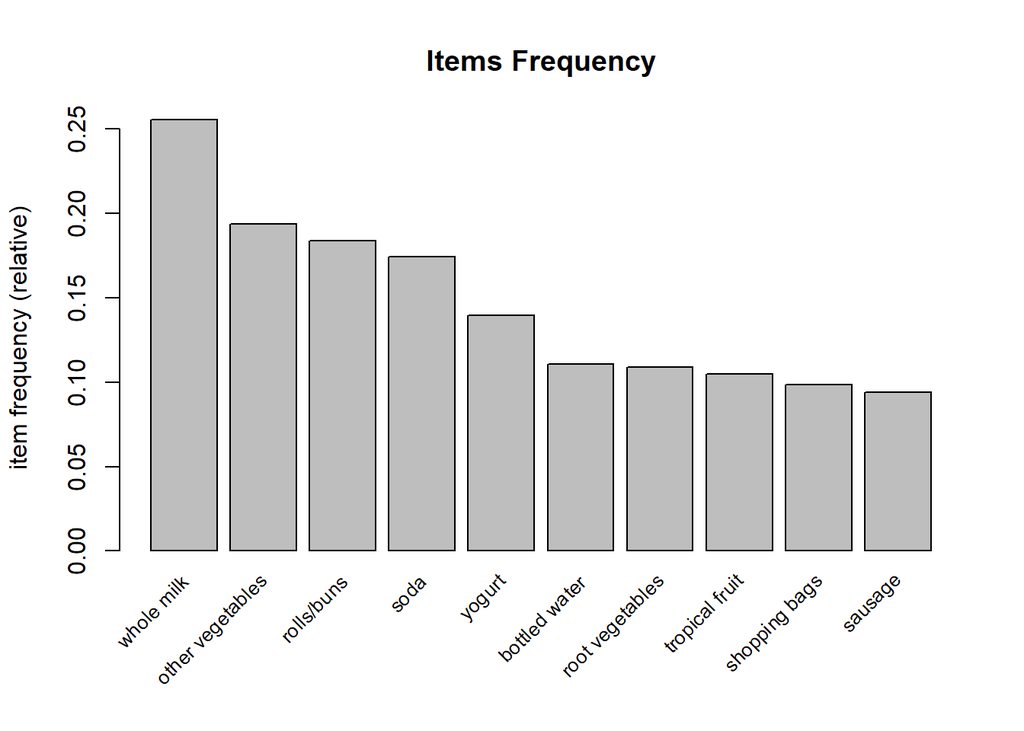

```r
itemFrequencyPlot(Groceries, topN=10, type="relative", main="Items Frequency", cex.names=0.8)
```

After I know which items are the most common, let’s look at which items are the least frequent. The function below lists 10 items with the loIst frequency ratio and is therefore the least interesting for the customers. It may be caused by the character of the store, or its prices. HoIver, those products should be considered by the store managers.

```r
head(sort(itemFrequency(Groceries), decreasing=FALSE), n=10)
```

```
##             baby food  sound storage medium preservation products
##          0.0001016777          0.0001016777          0.0002033554
##                  bags       kitchen utensil        baby cosmetics
##          0.0004067107          0.0004067107          0.0006100661
##        frozen chicken        toilet cleaner       make up remover
##          0.0006100661          0.0007117438          0.0008134215
##        salad dressing
##          0.0008134215
```

The count of items in basket is also of importance for the study. The diagram below shows the number of products distributed per basket.

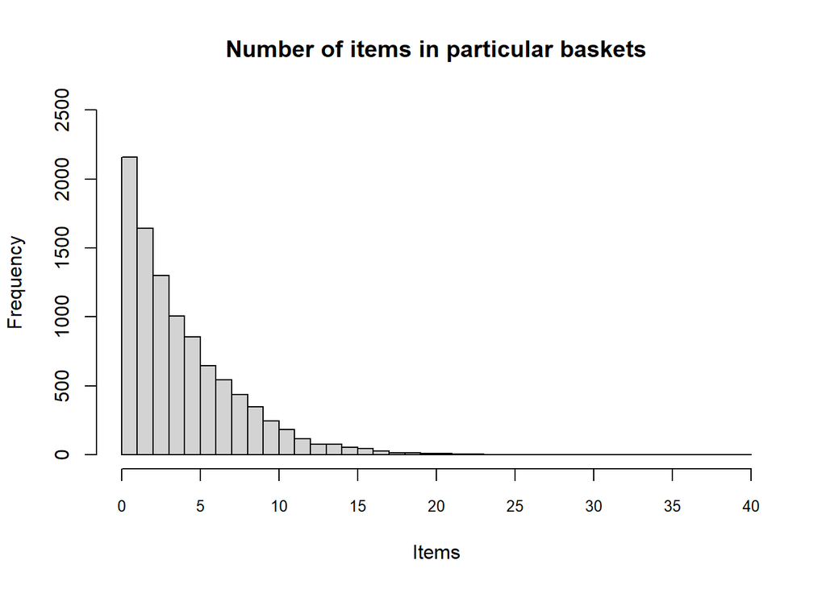

```r
hist(size(Groceries), breaks = 0:40, xaxt="n", ylim=c(0,2500),
     main = "Number of items in particular baskets", xlab = "Items")
axis(1, at=seq(0,40,by=5), cex.axis=0.8)
```

It can be seen that those consisting of one element are the most common itemsets. With the number of items the basket count decreases.

### Eclat Algorithm

The rules are based on the support and confidence level, so I have to define the level of those statistics. I need to do so to be able to analyze most frequent rules/patterns.

Firstly, by using eclat algorithm the most frequent item sets will be shown. The default support is 0.1 but in this dataset a lower value is required to obtain any results.

```r
itemsets<-eclat(Groceries, parameter=list(supp=0.01, minlen=2, maxlen=20))
```

```
## Eclat
##
## parameter specification:
##  tidLists support minlen maxlen            target  ext
##     FALSE    0.01      2     20 frequent itemsets TRUE
##
## algorithmic control:
##  sparse sort verbose
##       7   -2    TRUE
##
## Absolute minimum support count: 98
##
## create itemset ...
## set transactions ...[169 item(s), 9835 transaction(s)] done [0.00s].
## sorting and recoding items ... [88 item(s)] done [0.00s].
## creating sparse bit matrix ... [88 row(s), 9835 column(s)] done [0.00s].
## writing  ... [245 set(s)] done [0.00s].
## Creating S4 object  ... done [0.00s].
```

```r
inspect(head(itemsets))
```

```
##     items                          support    transIdenticalToItemsets count
## [1] {hard cheese,whole milk}       0.01006609  99                       99
## [2] {butter milk,whole milk}       0.01159126 114                      114
## [3] {butter milk,other vegetables} 0.01037112 102                      102
## [4] {ham,whole milk}               0.01148958 113                      113
## [5] {sliced cheese,whole milk}     0.01077783 106                      106
## [6] {oil,whole milk}               0.01128622 111                      111
```

The next stage of the study will be to induce the rules of the different itemsets. It will be done using the ruleInduction() function. The function needs at least three arguments: the Eclat algorithm’s output object, the fundamental dataset and the confidence parameter specification. Let’s assume two confidence levels 1 and 0.5 and check how many rules were set.

```r
rules <- ruleInduction(itemsets, Groceries, confidence=1)
rules
```

```
## set of 0 rules
```

```r
rules <- ruleInduction(itemsets, Groceries, confidence=0.5)
rules
```

```
## set of 15 rules
```

The rules can only be inspected if one assumes confidence at the 0.5 level. This means that the strength of the rules is between 100% and 50%. Let’s look at the mined rules now.

```r
inspect(rules)
```

```
##      lhs                                      rhs                support
## [1]  {curd,yogurt}                         => {whole milk}       0.01006609
## [2]  {butter,other vegetables}             => {whole milk}       0.01148958
## [3]  {domestic eggs,other vegetables}      => {whole milk}       0.01230300
## [4]  {whipped/sour cream,yogurt}           => {whole milk}       0.01087951
## [5]  {other vegetables,whipped/sour cream} => {whole milk}       0.01464159
## [6]  {other vegetables,pip fruit}          => {whole milk}       0.01352313
## [7]  {citrus fruit,root vegetables}        => {other vegetables} 0.01037112
## [8]  {root vegetables,tropical fruit}      => {whole milk}       0.01199797
## [9]  {root vegetables,tropical fruit}      => {other vegetables} 0.01230300
## [10] {tropical fruit,yogurt}               => {whole milk}       0.01514997
## [11] {root vegetables,yogurt}              => {whole milk}       0.01453991
## [12] {root vegetables,yogurt}              => {other vegetables} 0.01291307
## [13] {rolls/buns,root vegetables}          => {whole milk}       0.01270971
## [14] {rolls/buns,root vegetables}          => {other vegetables} 0.01220132
```

[output cut: 17 more lines]

First two-lhs and rhs-refer to the previous itemset (if I buy x …) and subsequent itemsets (… then I buy y), respectively.

### The Apriori Algorithm

The apriori algorithm utilizes a simple prior belief (hence the name a priori) about the properties of frequent items. Using this a priori belief, all subsets of frequent items must also be frequent. This makes it possible to limit the number of rules to search for. Although both algorithms work differently, the output obtained by Apriori algorithm inspecting rules is exactly the same as the output obtained by applying Eclat algorithm.

```r
summary(rules)
```

```
## set of 15 rules
##
## rule length distribution (lhs + rhs):sizes
##  3
## 15
##
##    Min. 1st Qu.  Median    Mean 3rd Qu.    Max.
##       3       3       3       3       3       3
##
## summary of quality measures:
##     support          confidence          lift          itemset
##  Min.   :0.01007   Min.   :0.5000   Min.   :1.984   Min.   : 54.0
##  1st Qu.:0.01174   1st Qu.:0.5151   1st Qu.:2.036   1st Qu.:138.0
##  Median :0.01230   Median :0.5245   Median :2.203   Median :208.0
##  Mean   :0.01316   Mean   :0.5411   Mean   :2.299   Mean   :174.4
##  3rd Qu.:0.01403   3rd Qu.:0.5718   3rd Qu.:2.432   3rd Qu.:220.5
##  Max.   :0.02227   Max.   :0.5862   Max.   :3.030   Max.   :238.0
##
## mining info:
##       data ntransactions support confidence
##  Groceries          9835    0.01        0.5
```

I can get summary information about the rules that give us some interesting information such as:

- The number of rules generated: 15
- The distribution of rules by length: Most rules are 3 items long
- The summary of quality measures: interesting to see ranges of support, lift, and confidence.
- The information on the data mined: total data mined, and minimum parameters.

I can visualize rules in a form of graph. The arrows shows the direction of the basket rule, eg. if a person buys citrus fruit, it is possible he will also buy other vegetables. The size of circles idicates the support rate and the color indicates the lift. It is easily seen which items are the most frequent combined, for example other vegetables, whole milk or yogurt.

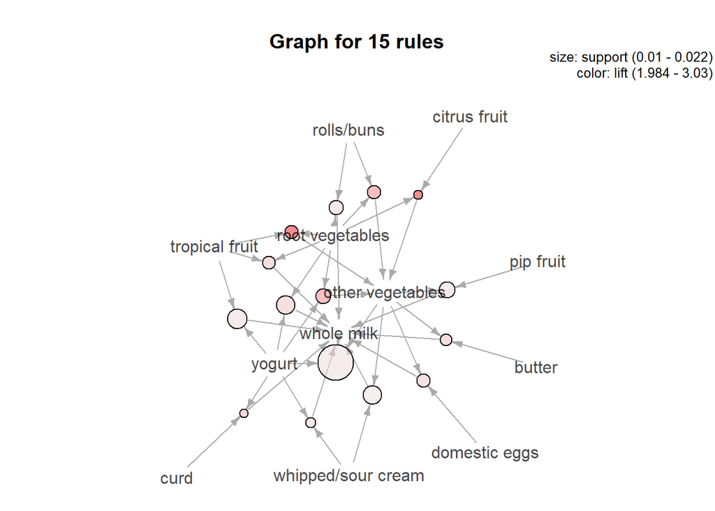

```r
library(arulesViz)
plot(rules, method="graph", shading="lift")
```

### Individual Rule Representation

```r
rules.milk <- apriori(data=Groceries,  parameter=list(supp=0.01, conf = 0.5, target="rules"), appearance = list(default="lhs", rhs="whole milk"), control=list(verbose=F))

rules.milk.byconf <- sort(rules.milk, by="confidence", decreasing=TRUE)

inspect(rules.milk.byconf)
```

```
##      lhs                                      rhs          support
## [1]  {curd,yogurt}                         => {whole milk} 0.01006609
## [2]  {butter,other vegetables}             => {whole milk} 0.01148958
## [3]  {root vegetables,tropical fruit}      => {whole milk} 0.01199797
## [4]  {root vegetables,yogurt}              => {whole milk} 0.01453991
## [5]  {domestic eggs,other vegetables}      => {whole milk} 0.01230300
## [6]  {whipped/sour cream,yogurt}           => {whole milk} 0.01087951
## [7]  {rolls/buns,root vegetables}          => {whole milk} 0.01270971
## [8]  {other vegetables,pip fruit}          => {whole milk} 0.01352313
## [9]  {tropical fruit,yogurt}               => {whole milk} 0.01514997
## [10] {other vegetables,yogurt}             => {whole milk} 0.02226741
## [11] {other vegetables,whipped/sour cream} => {whole milk} 0.01464159
##      confidence coverage   lift     count
## [1]  0.5823529  0.01728521 2.279125  99
## [2]  0.5736041  0.02003050 2.244885 113
## [3]  0.5700483  0.02104728 2.230969 118
## [4]  0.5629921  0.02582613 2.203354 143
## [5]  0.5525114  0.02226741 2.162336 121
## [6]  0.5245098  0.02074225 2.052747 107
## [7]  0.5230126  0.02430097 2.046888 125
## [8]  0.5175097  0.02613116 2.025351 133
## [9]  0.5173611  0.02928317 2.024770 149
## [10] 0.5128806  0.04341637 2.007235 219
## [11] 0.5070423  0.02887646 1.984385 144
```

Looking at the confidence, the strongest rule is that curd, yogurt -> whole milk. As to support, the strongest one is other vegetables, yogurt -> whole milk. The highest lift refers to curd, yogurt -> whole milk rule.

```r
rules.fruit <- apriori(data=Groceries,  parameter=list(supp=0.01, conf = 0.2, target="rules"), appearance = list(default="lhs", rhs="tropical fruit"), control=list(verbose=F))

rules.fruit.byconf <- sort(rules.fruit, by="confidence", decreasing=TRUE)

inspect(rules.fruit.byconf)
```

```
##     lhs                                   rhs              support
## [1] {other vegetables,yogurt}          => {tropical fruit} 0.01230300
## [2] {whole milk,yogurt}                => {tropical fruit} 0.01514997
## [3] {pip fruit}                        => {tropical fruit} 0.02043721
## [4] {other vegetables,root vegetables} => {tropical fruit} 0.01230300
## [5] {root vegetables,whole milk}       => {tropical fruit} 0.01199797
## [6] {citrus fruit}                     => {tropical fruit} 0.01992883
## [7] {other vegetables,whole milk}      => {tropical fruit} 0.01708185
## [8] {yogurt}                           => {tropical fruit} 0.02928317
##     confidence coverage   lift     count
## [1] 0.2833724  0.04341637 2.700550 121
## [2] 0.2704174  0.05602440 2.577089 149
## [3] 0.2701613  0.07564820 2.574648 201
## [4] 0.2596567  0.04738180 2.474538 121
## [5] 0.2453222  0.04890696 2.337931 118
## [6] 0.2407862  0.08276563 2.294702 196
## [7] 0.2282609  0.07483477 2.175335 168
## [8] 0.2099125  0.13950178 2.000475 288
```

Tropical fruits are chosen by consumers who also buy: other vegetables, yogurt according to highest confidence level. By the highest support level costumers who bought yogurt will also buy tropical fruits.

```r
rules.soda <- apriori(data=Groceries,  parameter=list(supp=0.01, conf = 0.2, target="rules"), appearance = list(default="lhs", rhs="soda"), control=list(verbose=F))

rules.soda.byconf <- sort(rules.soda, by="confidence", decreasing=TRUE)

inspect(rules.soda.byconf)
```

```
##      lhs                        rhs    support    confidence coverage
## [1]  {chocolate}             => {soda} 0.01352313 0.2725410  0.04961871
## [2]  {bottled water}         => {soda} 0.02897814 0.2621895  0.11052364
## [3]  {sausage}               => {soda} 0.02430097 0.2586580  0.09395018
## [4]  {fruit/vegetable juice} => {soda} 0.01840366 0.2545710  0.07229283
## [5]  {shopping bags}         => {soda} 0.02460600 0.2497420  0.09852567
## [6]  {white bread}           => {soda} 0.01026945 0.2439614  0.04209456
## [7]  {pastry}                => {soda} 0.02104728 0.2365714  0.08896797
## [8]  {napkins}               => {soda} 0.01199797 0.2291262  0.05236401
## [9]  {bottled beer}          => {soda} 0.01698017 0.2108586  0.08052872
## [10] {rolls/buns}            => {soda} 0.03833249 0.2084024  0.18393493
## [11] {pork}                  => {soda} 0.01189629 0.2063492  0.05765125
##      lift     count
## [1]  1.562939 133
## [2]  1.503577 285
## [3]  1.483324 239
## [4]  1.459887 181
## [5]  1.432194 242
## [6]  1.399044 101
## [7]  1.356665 207
## [8]  1.313969 118
## [9]  1.209209 167
## [10] 1.195124 377
## [11] 1.183350 117
```

The strongest rule seem to be chocolate -> soda with the confidence 0.27. The lift is 1.56. However, the most frequent rule on the list is rolls/buns -> soda.

Below one can see graphs of above mined rules.

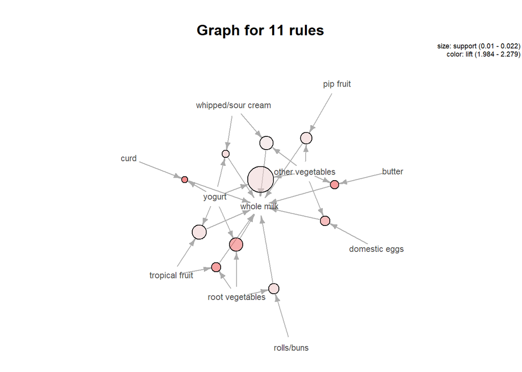

```r
plot(rules.milk, method="graph", cex=0.7, shading="lift")
```

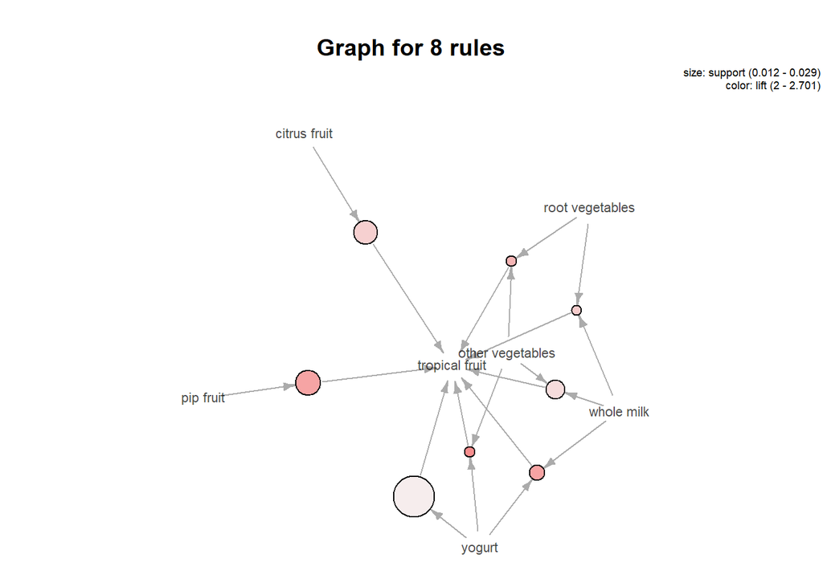

```r
plot(rules.fruit, method="graph", cex=0.7, shading="lift")
```

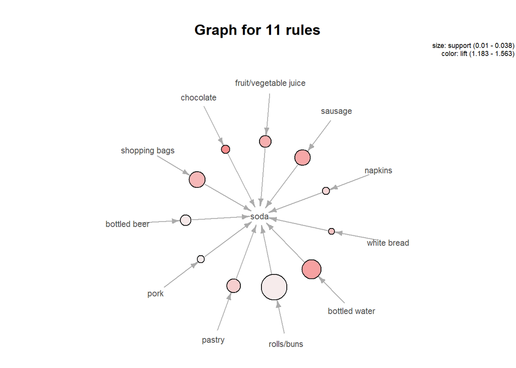

```r
plot(rules.soda, method="graph", cex=0.7, shading="lift")
```